# Classification_Muyodi_Based on polygon

Ronald Reagan Okoth

12/3/2021

```r
#knitr::opts_chunk$set(echo = FALSE)
knitr::opts_chunk$set(fig.width=12, fig.height=8, fig.path='Figs/',
                      echo=TRUE, warning=FALSE, message=FALSE)
```

### Install packages needed for this session

```r
library(raster)
library(sf)
library(sp)
library(rgdal)
library(dplyr)
library(tibble)
library(randomForest)
library(rasterVis)
library(ggplot2)
```

### Loading Data

- Define path to the raster images and the training data
- Read the shp file containing training data

```r
raster_path <-  '/Users/rragankonywa/OneDrive/Moyodi_classification/Data/Muyodi_images_2019/'
train_data_path <- '/Users/rragankonywa/OneDrive/Moyodi_classification/Data/training_data_clean4.shp'
# read the shp file
train_data <- st_read(train_data_path)[1]
# grab the crs of one of the raster files
raster_crs <- crs(stack(paste0(raster_path, list.files(raster_path)[1])))
#crs(train_data)
#crs(train_data)
```

### Data Processing

- Order the data based on the Name column then
- Create a column in the training data with unique class id for each landcover class

```r
train_data <- train_data[order(train_data$Name), ]
id = list()
all_Names <- train_data$Name
unique_Names <- unique(all_Names)

for(i in 1:length(unique_Names)){
  x <- all_Names[all_Names==unique_Names[i]]
  id <- append(id,rep(i, length(x))) %>%
    unlist()
}


train_data <- train_data %>%
  add_column(id, .before="Name")

train_data
```

```
## Simple feature collection with 41 features and 2 fields
## Geometry type: POLYGON
## Dimension:     XYZ
## Bounding box:  xmin: 593023.2 ymin: 9593015 xmax: 596362.5 ymax: 9594975
## z_range:       zmin: 0.9217594 zmax: 32.85673
## Projected CRS: WGS 84 / UTM zone 37S
## First 10 features:
##    id             Name                       geometry
## 1   1 Leucaena woodlot POLYGON Z ((595697.1 959385...
## 2   1 Leucaena woodlot POLYGON Z ((596153 9593767 ...
## 3   1 Leucaena woodlot POLYGON Z ((595490.1 959352...
## 4   1 Leucaena woodlot POLYGON Z ((596228.1 959472...
## 5   2       Maize farm POLYGON Z ((594552.8 959359...
## 6   2       Maize farm POLYGON Z ((594462.6 959388...
## 7   2       Maize farm POLYGON Z ((594495.4 959418...
## 8   3         Mangrove POLYGON Z ((594630.4 959305...
## 9   3         Mangrove POLYGON Z ((593179.8 959360...
## 10  3         Mangrove POLYGON Z ((593383.7 959346...
```

### Inspecting the Data

- Overlay the training polygons on an RGB image to visualize the data.
- Normally, one would need to make sure the crs of the shapefile and that of the raster are similar for the overlay to work properly

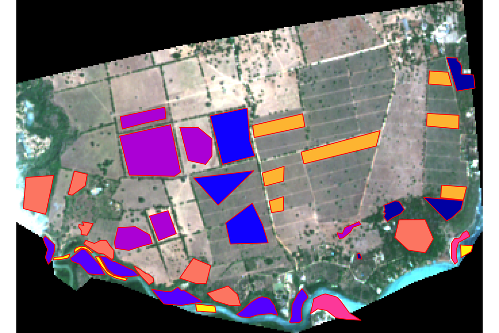

```r
sample_raster <- stack(paste0(raster_path, list.files(raster_path)[1]))
plotRGB(sample_raster, r=4,g=3,b=2, scale= 65535, stretch= "lin")
plot(train_data[1], add = TRUE, lwd = 2, ext = extent(sample_raster), border = "red")
```

```r
train_data <- st_zm(train_data)
```

### Automate Data Reading and stacking

```r
band_subset <- c(2,3,4,8)
raster_files <- list.files(raster_path, pattern = ".tif")
final_stack <- stack()
bandnames <- c("B", "G", "R", "NIR", "ndvi")
#bandnames <- c(paste0("B",1:12), "ndvi")
for(i in 1:length(raster_files)) {
  bandname <- unlist(lapply(bandnames, function(each){
    paste0(each,"_", "img", i)
  }))
  raster_image <- stack(paste0(raster_path, raster_files[i]))[[c(2,3,4,8)]]
  ndvi <- (raster_image[[4]]-raster_image[[3]])/(raster_image[[4]]+raster_image[[3]])
  #ndvi <- (raster_image[[8]]-raster_image[[4]])/(raster_image[[8]]+raster_image[[4]])
  raster_with_ndvi <- stack(raster_image,ndvi)
  names(raster_with_ndvi) <- bandname

  final_stack <- stack(final_stack,raster_with_ndvi)
}
```

### Mask the raster stack

- Load the boundary of the AOI and use it to mask the raster stack
- This is needed to remove the black areas with no data… the dark region around the RGB plot above

```r
roi <-  st_read("/Users/rragankonywa/OneDrive/Moyodi_classification/Data/plan A/polygon project Area/PA.shp") %>%
  st_transform(crs = crs(train_data))
final_stack <- mask(final_stack, roi)
```

### Extract Raster values using the training data

- Now extract raster values at each training point for each band in the final_stack

```r
train_df <- extract(final_stack, train_data, df = T, fun= mean)
```

- Add the class and id variables from the original train csv(train_data) as columns in the extracted values (train_df)

```r
train_df_final <- train_df %>%
  select(-ID) %>%
  add_column(train_data %>%
  select(id), .before="B_img1") %>%
  select(-geometry)

train_df_final <- train_df_final[complete.cases(train_df_final),]
```

### Model Building

- Fitting the model randomforest

```r
train_df_final$id <- factor(train_df_final$id)

# TODO: check proper settings of random forest algorithm
rfmodel <- randomForest(id ~., data = train_df_final, ntree =3000, nmtry = 400)
rfmodel
```

```
##
## Call:
##  randomForest(formula = id ~ ., data = train_df_final, ntree = 3000,      nmtry = 400)
##                Type of random forest: classification
##                      Number of trees: 3000
## No. of variables tried at each split: 9
##
##         OOB estimate of  error rate: 25%
## Confusion matrix:
##   1 2 3 4 5 6 7 8 class.error
## 1 1 0 0 0 0 2 0 0   0.6666667
## 2 0 0 0 0 0 0 3 0   1.0000000
## 3 0 0 4 0 0 0 0 0   0.0000000
## 4 0 0 0 5 0 0 1 0   0.1666667
## 5 0 0 0 1 0 0 0 0   1.0000000
## 6 2 0 0 0 0 6 0 0   0.2500000
## 7 0 0 0 0 0 0 7 0   0.0000000
## 8 0 0 0 0 0 0 0 4   0.0000000
```

### Class Prediction and Plotting

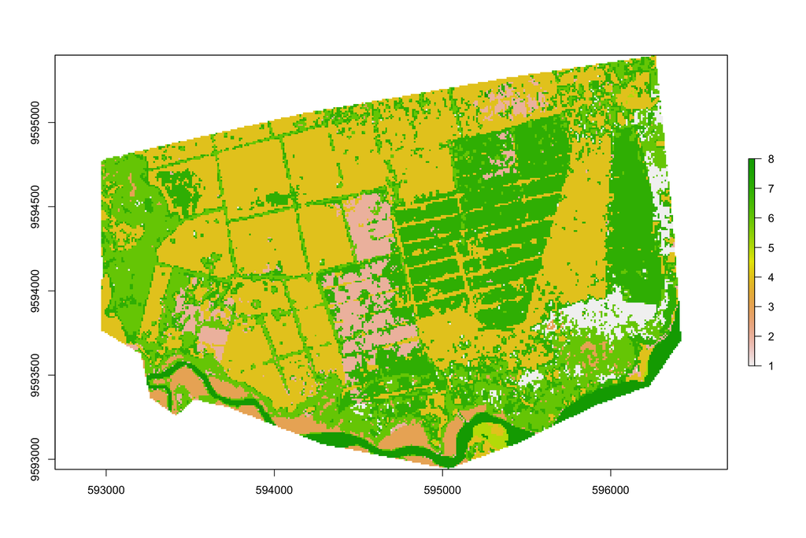

```r
predicted <- predict(final_stack, rfmodel)

plot(predicted)
```

```r
class_names <- train_data$Name %>%
  unique()
class_id <- train_data$id %>%
  unique()
#x <- as.data.frame(cbind(class_names,class_id))
classcolor <- c("#5475A8", "#B50000", "#D2CDC0", "#38814E", "#AF963C", "#D1D182", "#FBF65D", "#C8E6F8")
```

### Improved Plot

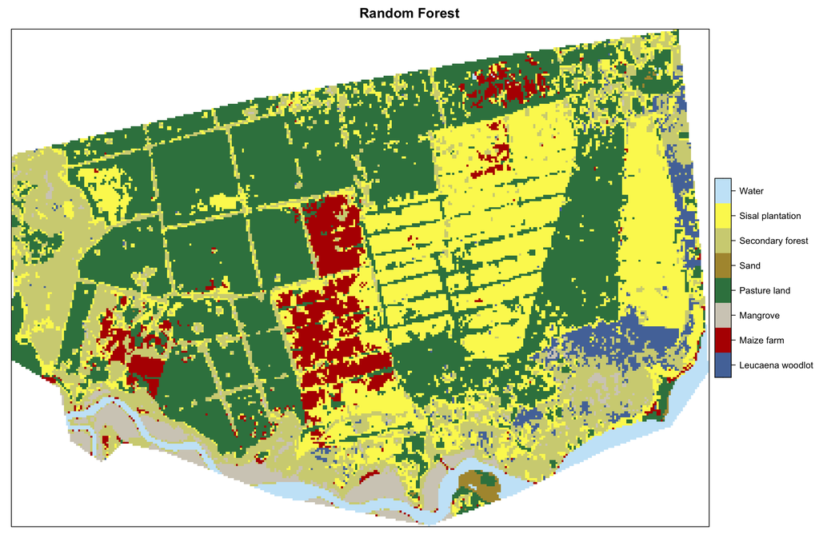

```r
predicted2 <- ratify(predicted)
predicted2 <- as.factor(predicted2)
rat <- levels(predicted2)[[1]]
rat[["zn"]] <- c(class_names)
levels(predicted2) <- rat

#rasterVis::levelplot(predicted2)

levelplot(predicted2, maxpixels = 1e6,
          col.regions = classcolor,
          scales=list(draw=FALSE),
          main = "Random Forest")
```